# Explaining suicide in Italian counties

Pietro Romozzi & Federico Colombo-Ercole

20 novembre 2014

## In short:

This study conducts an analysis on economical, social and climatic characteristics of a territory, aiming to assess the impact of these factors on suicide rates. Through a linear model the authors intend to answer whether climate factors affect suicides in the Italian context, considering 110 county-level observations whose data are provided by ISTAT. The main findings arinsing from the present work are:

- **Annual precipitations** has a negative impact on suicides.
- **Average temperatures** and **Temperature range** have no impact on suicide rate across Italy
- **GDP per capita** has a positive impact on suicides.
- **Population size** has a negative impact on suicides.

### Topic:

Several papers have tried to propose an explanatory framework to describe how climate conditions affect individuals’ mental health. Various WHO’s research papers have demonstrated that, among almost 90% of people who died by suicide in high-income countries, at least one mental disorder was present, while those affected by more than one mental disorder were experiencing significantly higher risks of committing suicide. The relationship between mental health (and the related suicide rates) and climate still needs to be studied into details, but so far, some scholars found evidence that, for example, extreme heat is a factor often associated with a general increase in aggressive, criminal and suicide rates (Bouchama A. 2007). Other evidences regard humidity as a with mental functioning, resulting in poorer concentration and elevated fatigue, while lack of sunlight causes anxiety and depression.

For these reasons, the debate about human health, and more specifically mental health, has been recently becoming more inclusive of climatic issues like climate conditions or climate change, and this research is meant to fill a research gap that currently exists with respect to suicides’ causes in Italy.

One reason why this work is potentially interesting is that, according to the latest WHO report concerning suicide prevention [see the latest report by (WHO 2014), “Globally, among young adults 15-29 years of age suicide accounts for 8.5% of all deaths and is ranked as the second leading cause of death (after traffic accidents). Among adults aged 30-49 years it accounts for 4.1% of all deaths and is ranked the fifth leading cause of death”. This research is going to focus on Italy, particularly at provincial level.

We believe that a focus on smaller-than-countries environments, does help in assessing how factors affecting suicides impact differently within the same country, thus highlighting a possible variance among regions which is overlooked by country-level aggregate data. In addition to this “micro-level” focus, we also intend to stress some environmental and climatic characteristics which could contribute to create “suicide-genic” environment.

We also do not neglect the use of more “orthodox” variables (i.e. related to economic and social dimensions) as control variables to develop a fairly comprehensive perspective. Looking for empirical evidence from Italian data, our aim is to add knowledge to existing literature reporting specific suicide patterns in Italy, among which we will look for evidence of the magnitude of climatic and environmental factors, believing that our wide-spectrum approach makes the present work interesting and innovative.

## Research questions:

As said above, this paper will focus on the relation between suicidal behaviors (an extreme consequence of mental disorders) and various factors concerning climate (Magnusson 2007) and socio-economic context.

In particular, the following hypothesis will be tested

- Suicide rate in a certain Italian county increases when the average temperature is low (Bouchama A. 2007).
- Suicide rate increases when the average temperature range is high
- Suicide rate increases when precipitations happen to be frequent.
- Suicide rate increases when GDP per capita is high (OECD 2013).
- Suicide rate increases according to economic inequality (represented by the gini index).
- Suicide rate increases whereby unemployment rate is higher.
- Suicide rate is higher in more populated counties.

## Methodology:

We decided to carry out our analysis on a single year given the time constraint this research is under. To have a significant result, we believed that recent data were necessary, so we identified 2009 as an acceptable compromise between proximity in time and availability of data for all of our variables. Most of the data required were founded in the Italian National Institute of Statistics (ISTAT) database, and fortunately the missing ones were available in other databases of ISTAT-related agencies or in the Eurostat database.

We firstly collected and downloaded all the data from ISTAT website (**http://www.istat.it/it/**) and from ISTAT-related agencies’ databases. A total of 110 observations, one for each Italian county, regarding a set of 9 different variables, is enough to estimate an appropriate model.

All the data gathered are processed using “R” (see R Core Team 2014). We use as well some packages developed for R, namely **ggplot2** (see Wickham and Chang 2014), **stargazer** (see Hlavac 2014), **repmis** (see Gandrud 2014), **car** (see Fox and Weisberg 2011), **knitr** (see Xie 2014) and **Zelig**.

### Case studies:

In a previous work, we tried to run a regression on regional data. However, we faced the big issue of not having enough observations, given that Italy counts 20 regions and it resulted in a statistically not significant model. This led us to move our analysis to a county-level, thus having available 110 observations. Eventually, in the present work we take into consideration all the Italian counties.

## Proposed Model:

For this paper’s scope, we conduct our analysis using a linear model, looking as follows:

$LogStSuicideRate = \alpha + \beta_{1}LogGDPPerCapita + \beta_{2}LogUnemploymentRate + \beta_{3}LogPopulation + \beta_{4}LogGiniIndex + \beta_{5}LogAverageTemperature + \beta_{6}LogAverageTemperatureRange + \beta_{7}LogAveragePrecipitations + e$

where variable *suicide rate* is defined as the standardized number of deaths by suicide every 100.000 inhabitants.

Variable *population* is a proxy of the degree of urbanization of the area. It describes the total number of people living in the county.

Variable *GDP per capita*, measuring GDP of a certain county divided by the population living there.

Variable *Gini Coefficient*, which varies between 0 and 1, expresses inequality among values of the frequency distribution of income for our target counties.

Variable *unemployment rate* refers to the share of the labor force that is without work but available for and seeking employment.

Variable *average temperature* simply corresponds to the value of the annual average temperature in a certain county expressed in Celsius degrees.

Variable *average temperature range* corresponds to the average difference between the maximum and the minimum temperature registered in the county, again expressed in Celsius degrees.

Variable *precipitations* measures the annual quantity of rain expressed in millimeters.

Variables are shown below in a scatterplot matrix where it is possible to observe how the variables are distributed and possible correlations among them. Having some skewed or not normal distributions, it was decided to adopt the logaritmic scale to provide a more reliable estimation.

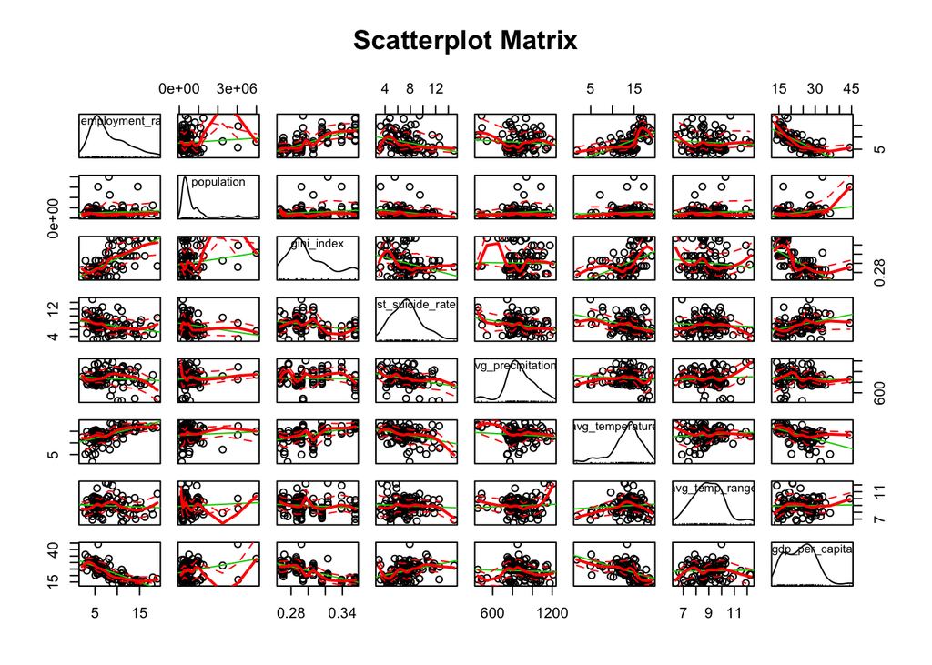

The model will show if our initial hypothesis that standardized suicide rates of each one of the 110 Italian provinces is affected by climate and environmental factors.

Unemployment rate, gini index and variables regarding temperatures appear not statistically significant during a first model estimation, thus we proceed with further simplification of our initial model, gradually dropping those variables looking for model improvements. Thus, we propose a second, more reliable model, using four independent variables which looks as follows:

$SuicideRate = \alpha + \beta_{1}GdpPerCapita + \beta_{2}Population + \beta_{3}AverageTemperature + \beta_{4}AveragePrecipitations + e$

According to this second estimation, a one percent increase in GDP per capita increases the standardized suicide rate by 0,529 percent. The effect of population size is slightly reduced though, being the new coefficient 0,158. A one percent increase in average precipitations now decreases suicide rates in Italian provinces by 0,461 percent.

**Estimation of the Second Model**

|  | *Dependent variable:* |
| --- | --- |
|  | St. suicide rate |
| GDP per capita | 0.529*** |
|  | (0.117) |
| Population | -0.158*** |
|  | (0.039) |
| Average Temperatures | -0.069 |
|  | (0.092) |
| Average Precipitations | -0.461*** |
|  | (0.143) |
| Constant | 5.622*** |
|  | (1.123) |
| Observations | 103 |
| R<sup>2</sup> | 0.365 |
| Adjusted R<sup>2</sup> | 0.339 |
| Residual Std. Error | 0.261 (df = 98) |
| F Statistic | 14.086*** (df = 4; 98) |
| *Note:* | p<0.1; p<0.05; p<0.01 |

## Main findings and discussion:

The goal of this research was to test if suicide behaviors are influenced by factors other than socioeconomic indicators. Therefore, it was decided to include variables controlling for climate characteristics like yearly average temperature and precipitations and temperature range, in order to fill a research gap, since not many studies have tried to explain if climate indeed has an effect on suicidal behavior, and to test an hypothesis that the authors of this paper found to be interesting. Interestingly, the level of precipitations *negatively* affects suicide rate and not positively, as it is commonly believed. The magnitude of this relation (coefficient = -0,461) is not remarkably strong, but the result is statistically significant. A graphical representation of the correlation is shown below.

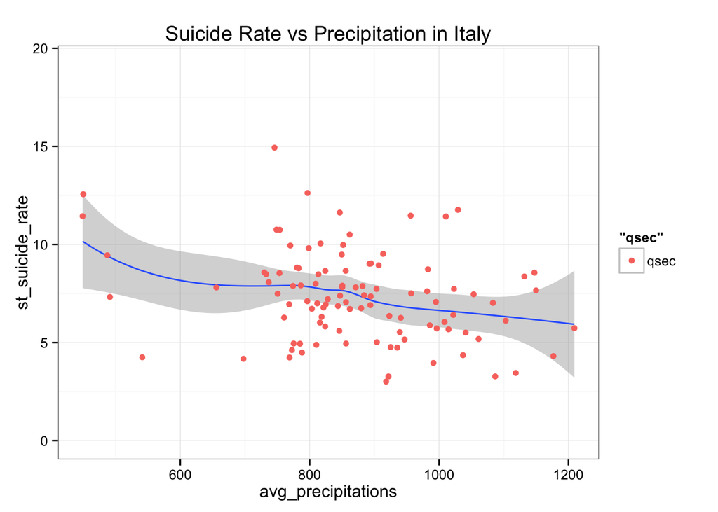

Regarding the other variables we included in our model, only GDP per capita and population size resulted to be statistically significant. GDP per capita resulted in having a positive impact on suicide rate in Italy, a phenomenon that is not new (Hilario Blasco-Fontecilla 2011). Also population size has a moderate impact on standardized suicide rate. In particular, a one percent increase in population size decreases suicide rate by 0,158 percent.

A post estimation simulation was also conducted by setting the range between 650 and 1200 mm of average rainfall during year 2009. The output table again shows that standardized suicide rates are expected to decrease from 8 to less than 6 deaths every 100.000 inhabitants, as precipitations increase to up to 1200 mm per year.

How to cite this model in Zelig: Kosuke Imai, Gary King, and Olivia Lau. 2014. “ls: Least Squares Regression for Continuous Dependent Variables” in Kosuke Imai, Gary King, and Olivia Lau, “Zelig: Everyone’s Statistical Software,” http://gking.harvard.edu/zelig

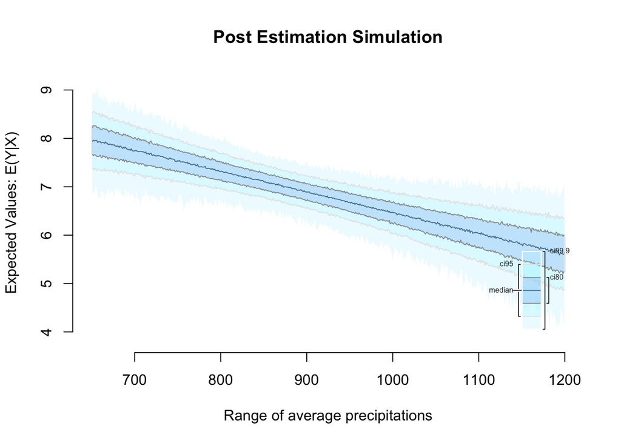

## Conclusions and limitations:

In conclusion, among the climate factors considered in the present analysis, only annual average precipitation seems to influence suicide rate in the Italian context on 2009. The reason for this is that most of suicides take place in Spring and Summer, when heat and humidity affect body cooling, thus causing psychological and behavioral change, which may predispose a person to para suicidal behavior (OECD 2013). Interestingly, rain negatively affects suicide rates in Italian provinces instead of being positively correlated to suicidal behaviors, as it is commonly believed. Our study backs this finding bringing evidence about the impact of precipitations, however it does not provide specific reasons for that affecting suicides, so further developments in this field might be consider the mechanisms through which rain has such a positive influence on mental health.

Overall, to get more precise and interesting results, the same research methodology should be applied to other developed countries, to test if the relationship between precipitations and suicide rate holds true only in the Italian context or also elsewhere; Another stimulus for further research might be extending the analysis including data of years other than 2009, perhaps implementing a panel analysis. Lastly, being 2009 the first year when most of OECD countries, including Italy, experienced the most severe recession since World War Two, data regarding suicide rates might be biased.

References:

Bouchama A., Mohamed G., Dehbi M. 2007. “Prognostic Factors in Heat Wave Related Deaths: a Meta-Analysis.” *Arch Intern Med.*, no. 20: 2170–76.

Fox, John, and Sanford Weisberg. 2011. *An R Companion to Applied Regression*. Second. Thousand Oaks CA: Sage. http://socserv.socsci.mcmaster.ca/jfox/Books/Companion.

Gandrud, Christopher. 2014. *repmis: A Collection of Miscellaneous Tools for Reproducible Research with R.* http://CRAN.R-project.org/package=repmis.

Hilario Blasco-Fontecilla, Rebeca Garcia-Nieto1, Mercedes Perez-Rodriguez. 2011. “Worldwide Impact of Economic Cycles on Suicide Trends over 3 decades: differences According to Level of Development. A Mixed Effect Model Study.” *BMJ Open*.

Hlavac, Marek. 2014. *stargazer: LaTeX/HTML Code and ASCII Text for Well-Formatted Regression and Summary Statistics Tables*. Cambridge, USA: Harvard University. http://CRAN.R-project.org/package=stargazer.

Magnusson, A. 2007. “An Overview of Epidemiological Studies on Seasonal Affective Disorder.” *Acta Psychiatria Scand.*, no. 101: 176–84.

OECD. 2013. “Health at a Glance 2013: OECD.” http://dx.doi.org/10.1787/health_glance-2013-en.

R Core Team. 2014. *R: A Language and Environment for Statistical Computing*. Vienna, Austria: R Foundation for Statistical Computing. http://www.R-project.org/.

WHO. 2014. “Preventing Suicide: a Global Imperative.”

Wickham, Hadley, and Winston Chang. 2014. *ggplot2: An Implementation of the Grammar of Graphics*. http://CRAN.R-project.org/package=ggplot2.

Xie, Yihui. 2014. *knitr: A General-Purpose Package for Dynamic Report Generation in R*. http://yihui.name/knitr/.